# IODS Final Project

Abera Temesgen

15 December 2017

# Abstract

In this assignment, it is attempted to determine whether there is a linear relationship between an independent variable(crime rate) and three explanatory variables(index of accessibility to radial highways, percentage of lower status of population, and property tax rate) utilizing readily availabe Boston data in r MASS package. Three statistical methods(Linear regression, logistic regression and Principal Component analysis) were used to carryout the analsyis. The regression result indicated that crime rate has linear, positive and statistically significant relation with index of accessibility to radial highways and percentage of lower status of population, with an r square of 0.42. Moreover, compared to the percentage of lower status of population, crime rate variation is more strongly explained by index of accessibility to radial highways in Boston. On the other hand,PCA analysis showed that the first and the second principal components reflects 46.8% and 11.8% of the total variations in the original boston data.

# Introduction

Welcome to my final assignment page. In this exercise, we will investigate whether there is a meaningful relationship between per capita crime rate in 506-towns in Boston(USA), and percentage of lower status of the population in the towns and full-value property-tax rate. The data source will be from the Boston data in the r MASS package.

Related to the research problem, three hypothesis are stated as follows:

**Hypothesis 1: Increase in the index of accessibility to radial highways in towns favors high crime rate**

**Hypothesis 2: Crime rates increase with high percentage of lower status of population**

**Hypothesis 3: Crime rates inrease in rich towns as indicated by their high property tax rate**

To test these hypothesis, I will use two statistical methods:linear and logistic regression. Linear regression is a statistical method to identify the extent to which there is a linear relationship between a dependent variable and one or more independent variabels. The independent variables are used to predict the values of the dependent(response) variable. The dependent variables must be measured on a continious measurement sale(i.g. 0-100) while the independent variable(s) can be measured on either a continous or categorical measurement scale. In order to qualify for linear regression, the data must satisfy some key assumptions:(1) there must be a linear relationship between the dependent variable and the independent variables, (2) independent variables are not highly correlated with each other, and (3) the variance of error terms are similar across the values of the independent variables.

Logistics regressions is a special type of regression where binary response variable is related to a set of explanatory variables, which can be discrete and/or continuous.In logistic regression Probability or Odds of the response taking a particular value is modeled based on combination of values taken by the predictors.Logistic regression is applicable if we want to: classify individuals into two categories based on explanatory variables, predict probabilities that individuals fall into two categories of the binary response as a function of some explanatory variables, perform descriptive discriminate analyses such as describing the differences between individuals in separate groups as a function of explanatory variables, etc.

Moreover, to reduce the dimensionality of the original Boston data, principal component anlysis (PCA) will be used at later section (see PCA). PCA is a dimension-reduction tool that can be used to reduce a large set of variables to a small set that still contains most of the information in the large set by transforming a number of correlated variables into a smaller number of uncorrelated variables called principal components.The first principal component accounts for as much of the variability in the data as possible, and each succeeding component accounts for as much of the remaining variability as possible.

# Linear and logistic regression, and Principal Component Analysis using Boston data

## Data description

The Boston data contain infromation about housing values in the suburbs of Boston, USA. There are 506 observations of 14 variables in the dataset.The variables are:

**crim**- per capita crime rate by town.

**zn** - proportion of residential land zoned for lots over 25,000 sq.ft.

**indus**- proportion of non-retail business acres per town.

**chas** - Charles River dummy variable (= 1 if tract bounds river; 0 otherwise).

**nox** - nitrogen oxides concentration (parts per 10 million).

**rm** - average number of rooms per dwelling.

**age** - proportion of owner-occupied units built prior to 1940.

**dis** - weighted mean of distances to five Boston employment centres.

**rad** - index of accessibility to radial highways.

**tax** - full-value property-tax rate per $10,000.

**ptratio**- pupil-teacher ratio by town.

**black** -1000(Bk - 0.63)^2 where Bk is the proportion of blacks by town.

**lstat** -lower status of the population (percent).

**medv** -median value of owner-occupied homes in $1000s.

**For the linear and logistic regression, we’ll use the wrangled data from the local folder**

**Link to data wrangling file** https://github.com/temesgen1858/IODS-final/blob/master/data/data_wrangling.R

*Read data from local folder*

```r
Boston_analysis <-read.table("D:/final_assignment/IODS-final/boston_new.csv",sep = ";", header = TRUE)
df<- Boston_analysis
str(df)
```

```
## 'data.frame':    506 obs. of  5 variables:
##  $ crim          : num  0.00632 0.02731 0.02729 0.03237 0.06905 ...
##  $ lstat         : num  4.98 9.14 4.03 2.94 5.33 ...
##  $ rad           : int  1 2 2 3 3 3 5 5 5 5 ...
##  $ tax           : int  296 242 242 222 222 222 311 311 311 311 ...
##  $ high_crim_rate: logi  FALSE FALSE FALSE FALSE FALSE FALSE ...
```

```r
dim(df)
```

```
## [1] 506   5
```

## Linear regression analysis

*Build the regression model and print the summary*

```r
model=lm(crim~lstat+rad+tax, data=df)
summary(model)
```

```
##
## Call:
## lm(formula = crim ~ lstat + rad + tax, data = df)
##
## Residuals:
##    Min     1Q Median     3Q    Max
## -8.916 -1.874 -0.271  0.969 76.740
##
## Coefficients:
##              Estimate Std. Error t value Pr(>|t|)
## (Intercept) -3.961613   1.103352  -3.591 0.000362 ***
## lstat        0.243350   0.048759   4.991 8.30e-07 ***
## rad          0.555130   0.081028   6.851 2.15e-11 ***
## tax         -0.001972   0.004353  -0.453 0.650667
## ---
## Signif. codes:  0 '***' 0.001 '**' 0.01 '*' 0.05 '.' 0.1 ' ' 1
##
## Residual standard error: 6.564 on 502 degrees of freedom
## Multiple R-squared:  0.421,  Adjusted R-squared:  0.4176
## F-statistic: 121.7 on 3 and 502 DF,  p-value: < 2.2e-16
```

The results of the regression show that the “lstat”" and “rad” have statistically significant (P<0.05) and positive relation with crime whereas tax does not. Therefore let’s re-run the model by removing the statistically insignificant variable (tax).

```r
model=lm(crim~lstat+rad, data=df)
summary(model)
```

```
##
## Call:
## lm(formula = crim ~ lstat + rad, data = df)
##
## Residuals:
##    Min     1Q Median     3Q    Max
## -8.953 -1.881 -0.249  1.040 76.726
##
## Coefficients:
##             Estimate Std. Error t value Pr(>|t|)
## (Intercept) -4.38141    0.59872  -7.318 1.00e-12 ***
## lstat        0.23728    0.04685   5.065 5.75e-07 ***
## rad          0.52281    0.03842  13.607  < 2e-16 ***
## ---
## Signif. codes:  0 '***' 0.001 '**' 0.01 '*' 0.05 '.' 0.1 ' ' 1
##
## Residual standard error: 6.559 on 503 degrees of freedom
## Multiple R-squared:  0.4208, Adjusted R-squared:  0.4185
## F-statistic: 182.7 on 2 and 503 DF,  p-value: < 2.2e-16
```

Now, the regression result can be written as: **crim = 0.52281xrad + 0.23728xlstat - 4.38141** (i.e, For a unit increase in “rad” and “lstat” the crime rate will increase by 0.52281 and 0.23728, respectively). The F-statistics value(182.7) also increased after removing the insignificant variable(“tax”) and it’s value is quiet larger than 1 indicating that a relation exisits between the dependent and predictor variabels and it’s enough to rejevt the null hypothesis. Moreover,larger t values (5.065 and 13.607 stadard deviation) further suggests rejection of the null hypothesis.

As the residul standard error indicates the model prediction (crime rate) can deviate by 6.559 from the actual value. Also, the multiple r-square shows that model fits the data only around 42.1% (0.421), meaning only 42.1% of the variance in crime percentage is explained by “rad” and “lstat” and hence the model shows relatively low performace.

Let’s further check the validity of the linear regression model assumptions (normality, linearity, and influential value).

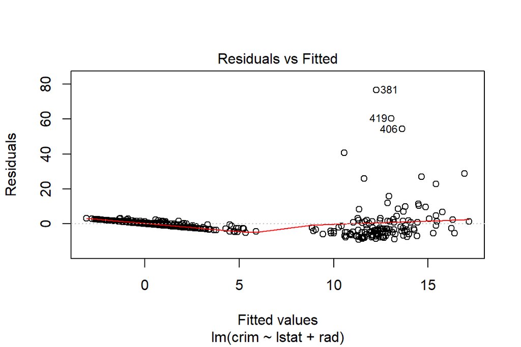

```r
plot(model,1)
```

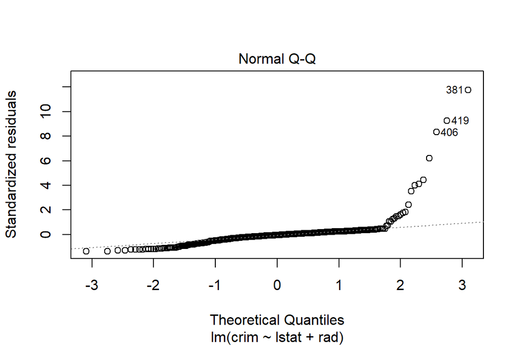

```r
plot(model,2)
```

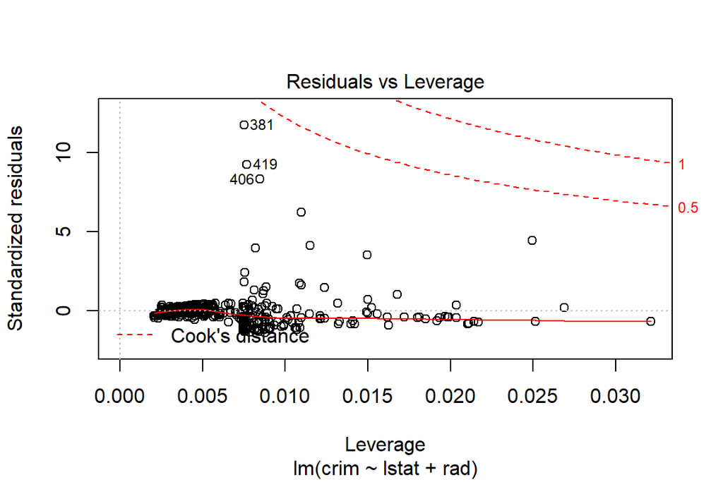

```r
plot(model,5)
```

The residual vs leverage result displayed that the slope of the model is not affecetd by the influential points(381,419 and 406) as they are below 0.5 cook’s distnace.

Let’s use another method (logistic regression) to anlyze the relationship again using the wrangled Boston data.

```r
library(dplyr)
```

```r
library(tidyr)
library(ggplot2)
Boston_analysis <-read.table("D:/final_assignment/IODS-final/boston_new.csv",sep = ";", header = TRUE)
df<-Boston_analysis
#sumaries of the statstics and  plot (bar and box plot)
summary(df)
```

```
##       crim              lstat            rad              tax
##  Min.   : 0.00632   Min.   : 1.73   Min.   : 1.000   Min.   :187.0
##  1st Qu.: 0.08204   1st Qu.: 6.95   1st Qu.: 4.000   1st Qu.:279.0
##  Median : 0.25651   Median :11.36   Median : 5.000   Median :330.0
##  Mean   : 3.61352   Mean   :12.65   Mean   : 9.549   Mean   :408.2
##  3rd Qu.: 3.67708   3rd Qu.:16.95   3rd Qu.:24.000   3rd Qu.:666.0
##  Max.   :88.97620   Max.   :37.97   Max.   :24.000   Max.   :711.0
##  high_crim_rate
##  Mode :logical
##  FALSE:294
##  TRUE :212
##  NA's :0
##
##
```

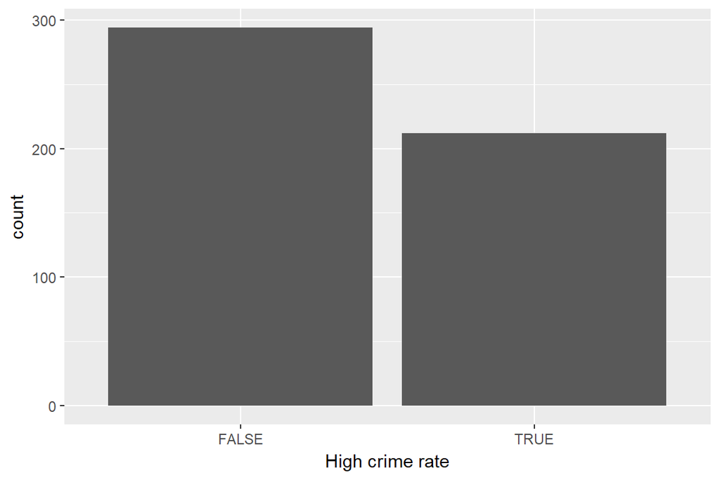

```r
g1 <- ggplot(data=df,aes(x=high_crim_rate))
g1+geom_bar()+xlab("High crime rate")
```

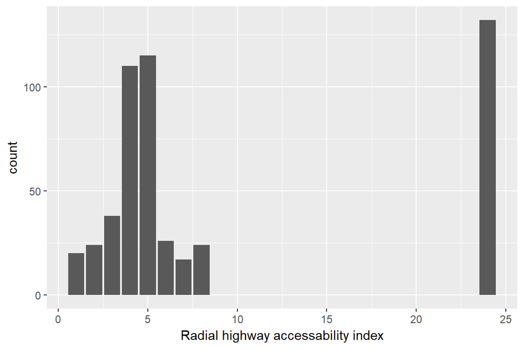

```r
g2 <- ggplot(data=df,aes(x=rad))
g2 + geom_bar()+xlab("Radial highway accessability index")
```

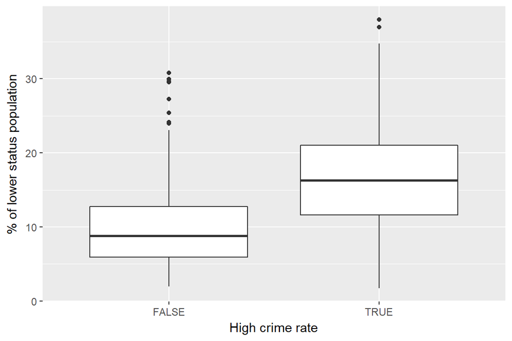

```r
g3 <- ggplot(data=df,aes(x=high_crim_rate,y=lstat))
g3 + geom_boxplot()+ylab("% of lower status population") + xlab("High crime rate")
```

With high crime rate(True), the % of lower status population is high. Similarly low crime rate is noticed in towns with small % of lower class population.

Around 200 towns have morethan 50% crime rate whereas most towns(around 300) have lower crime rate, i.e. less than 50%.

## Logistic regression analysis

```r
#Logistic regression to test the hypothesis

m2 <- glm(high_crim_rate ~ rad + lstat + tax , data = Boston_analysis, family = "binomial")

# print out a summary of the model
summary(m2)
```

```
##
## Call:
## glm(formula = high_crim_rate ~ rad + lstat + tax, family = "binomial",
##     data = Boston_analysis)
##
## Deviance Residuals:
##      Min        1Q    Median        3Q       Max
## -1.74151  -0.64427  -0.39442   0.08335   2.09539
##
## Coefficients:
##              Estimate Std. Error z value Pr(>|z|)
## (Intercept) -4.621442   0.560731  -8.242  < 2e-16 ***
## rad          0.281186   0.062030   4.533 5.81e-06 ***
## lstat        0.080300   0.021982   3.653 0.000259 ***
## tax          0.003350   0.001615   2.075 0.038007 *
## ---
## Signif. codes:  0 '***' 0.001 '**' 0.01 '*' 0.05 '.' 0.1 ' ' 1
##
## (Dispersion parameter for binomial family taken to be 1)
##
##     Null deviance: 688.12  on 505  degrees of freedom
## Residual deviance: 358.81  on 502  degrees of freedom
## AIC: 366.81
##
## Number of Fisher Scoring iterations: 7
```

```r
# print out the coefficients of the model
coef(m2)
```

```
##  (Intercept)          rad        lstat          tax
## -4.621442008  0.281185734  0.080299566  0.003350249
```

```r
#print out the odd ration from coefficients of the model
ODR <- coef(m2) %>% exp

#compute confidence intervals (CI)
CI <- confint(m2) %>% exp
cbind(ODR, CI)
```

```
##                     ODR      2.5 %     97.5 %
## (Intercept) 0.009838598 0.00295584 0.02737144
## rad         1.324699623 1.19233723 1.52426951
## lstat       1.083611632 1.03811279 1.13201205
## tax         1.003355867 1.00020684 1.00661575
```

```r
# predict the probability of high_crim_rate
probabilities <- predict(m2, type = "response")

# add the predicted probabilities to 'Boston_analysis'
Boston_analysis <- mutate(Boston_analysis, probability = probabilities)

# use the probabilities to make a prediction of high_crim_rate
Boston_analysis <- mutate(Boston_analysis, prediction = probability>0.5)

# see the last thirty original classes, predicted probabilities, and class predictions
dplyr::select(Boston_analysis, rad,lstat, high_crim_rate, probability, prediction) %>% tail(30)
```

```
##     rad lstat high_crim_rate probability prediction
## 477  24 18.68           TRUE  0.99715197       TRUE
## 478  24 24.91           TRUE  0.99827111       TRUE
## 479  24 18.03           TRUE  0.99699983       TRUE
## 480  24 13.11           TRUE  0.99555273       TRUE
## 481  24 10.74           TRUE  0.99462549       TRUE
## 482  24  7.74           TRUE  0.99317151       TRUE
## 483  24  7.01           TRUE  0.99276225       TRUE
## 484  24 10.42           TRUE  0.99448637       TRUE
## 485  24 13.34           TRUE  0.99563376       TRUE
## 486  24 10.58           TRUE  0.99455637       TRUE
## 487  24 14.98           TRUE  0.99617044       TRUE
## 488  24 11.45           TRUE  0.99492182       TRUE
## 489   4 18.06          FALSE  0.58310626       TRUE
## 490   4 23.97          FALSE  0.69213262       TRUE
```

[output cut: 16 more lines]

```r
table(high_use = Boston_analysis$high_crim_rate, prediction = Boston_analysis$prediction )
```

```
##         prediction
## high_use FALSE TRUE
##    FALSE   287    7
##    TRUE     73  139
```

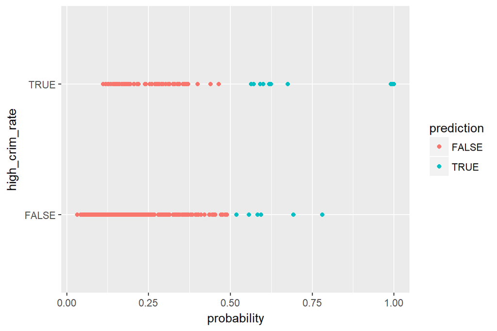

```r
# Display graphically
m3 <- ggplot(Boston_analysis, aes(x = probability, y=high_crim_rate, col=prediction))

# define the geom as points and draw the plot
m3+geom_point()
```

```r
# calculate training error
loss_func <- function(class, prob) {
  n_wrong <- abs(class - prob) > 0.5
  mean(n_wrong)
}

loss_func(class = Boston_analysis$high_crim_rate, prob = Boston_analysis$probability)
```

```
## [1] 0.1581028
```

Now let’s read the whole Boston data this time for the principal component analysis to reduce the number of dimensions

## Principal Component Analysis

```r
library(dplyr)
library(GGally)
library(MASS)
data("Boston")
str(Boston)
```

```
## 'data.frame':    506 obs. of  14 variables:
##  $ crim   : num  0.00632 0.02731 0.02729 0.03237 0.06905 ...
##  $ zn     : num  18 0 0 0 0 0 12.5 12.5 12.5 12.5 ...
##  $ indus  : num  2.31 7.07 7.07 2.18 2.18 2.18 7.87 7.87 7.87 7.87 ...
##  $ chas   : int  0 0 0 0 0 0 0 0 0 0 ...
##  $ nox    : num  0.538 0.469 0.469 0.458 0.458 0.458 0.524 0.524 0.524 0.524 ...
##  $ rm     : num  6.58 6.42 7.18 7 7.15 ...
##  $ age    : num  65.2 78.9 61.1 45.8 54.2 58.7 66.6 96.1 100 85.9 ...
##  $ dis    : num  4.09 4.97 4.97 6.06 6.06 ...
##  $ rad    : int  1 2 2 3 3 3 5 5 5 5 ...
##  $ tax    : num  296 242 242 222 222 222 311 311 311 311 ...
##  $ ptratio: num  15.3 17.8 17.8 18.7 18.7 18.7 15.2 15.2 15.2 15.2 ...
##  $ black  : num  397 397 393 395 397 ...
##  $ lstat  : num  4.98 9.14 4.03 2.94 5.33 ...
##  $ medv   : num  24 21.6 34.7 33.4 36.2 28.7 22.9 27.1 16.5 18.9 ...
```

```r
dim(Boston)
```

```
## [1] 506  14
```

```r
#standardize the variables as principal componet analysis is sensitive to data scaling

boston_std <- scale(Boston)
pca_boston <- prcomp(boston_std)
s <- summary(pca_boston)
s
```

```
## Importance of components:
##                           PC1    PC2     PC3     PC4     PC5     PC6
## Standard deviation     2.5585 1.2843 1.16142 0.94156 0.92244 0.81241
## Proportion of Variance 0.4676 0.1178 0.09635 0.06332 0.06078 0.04714
## Cumulative Proportion  0.4676 0.5854 0.68174 0.74507 0.80585 0.85299
##                            PC7     PC8    PC9    PC10   PC11    PC12
## Standard deviation     0.73172 0.63488 0.5266 0.50225 0.4613 0.42777
## Proportion of Variance 0.03824 0.02879 0.0198 0.01802 0.0152 0.01307
## Cumulative Proportion  0.89123 0.92003 0.9398 0.95785 0.9730 0.98612
##                           PC13    PC14
## Standard deviation     0.36607 0.24561
## Proportion of Variance 0.00957 0.00431
## Cumulative Proportion  0.99569 1.00000
```

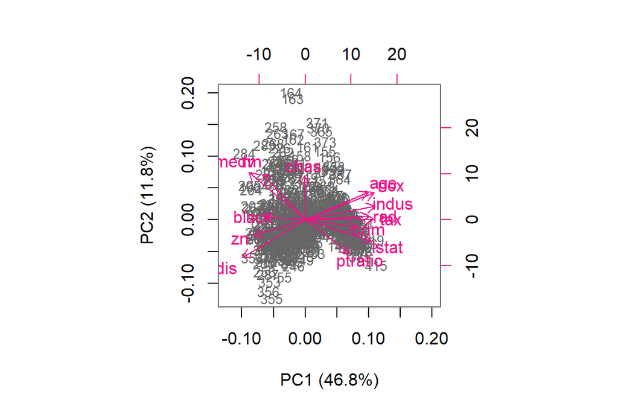

```r
pca_rou <- round(100*s$importance[2, ], digits = 1)

# create object pc_lab to be used as axis labels
pc_lab <- paste0(names(pca_rou), " (", pca_rou, "%)")

# draw a biplot
biplot(pca_boston, cex = c(0.8, 1), col = c("grey40", "deeppink2"), xlab = pc_lab[1], ylab = pc_lab[2])
```

```r
#Lets gets the contributions of  variables to each each principla components from the loadings
pca_boston2 <- princomp(boston_std, cor=TRUE, score=TRUE)
pca_boston2$loadings
```

```
##
## Loadings:
##         Comp.1 Comp.2 Comp.3 Comp.4 Comp.5 Comp.6 Comp.7 Comp.8 Comp.9
## crim     0.242         0.395  0.100        -0.225  0.777  0.157  0.254
## zn      -0.245  0.148  0.395  0.343  0.114 -0.336 -0.274 -0.380  0.383
## indus    0.332 -0.127                             -0.340  0.172  0.627
## chas           -0.411 -0.125  0.700 -0.535  0.163
## nox      0.325 -0.254                0.195 -0.149 -0.198
## rm      -0.203 -0.434  0.353 -0.293         0.131        -0.438
## age      0.297 -0.260 -0.201         0.150         0.119 -0.588
## dis     -0.298  0.359  0.157  0.185 -0.106        -0.104 -0.128 -0.176
## rad      0.303         0.419        -0.230 -0.135 -0.137        -0.463
## tax      0.324         0.343        -0.163 -0.188 -0.314        -0.179
## ptratio  0.208  0.315        -0.342 -0.616  0.279        -0.283  0.275
## black   -0.197        -0.361 -0.202 -0.367 -0.786
## lstat    0.311  0.201 -0.161  0.243  0.178               -0.357 -0.172
## medv    -0.267 -0.445  0.163 -0.180                       0.152
##         Comp.10 Comp.11 Comp.12 Comp.13 Comp.14
## crim
## zn      -0.246  -0.128  -0.221  -0.132
## indus    0.255   0.274   0.348          -0.235
## chas
## nox      0.212  -0.437  -0.449   0.525
## rm       0.526   0.224  -0.126
## age     -0.246  -0.330   0.486
## dis      0.299  -0.115   0.494   0.552
## rad     -0.116                          -0.635
## tax                      0.170  -0.243   0.699
## ptratio -0.160          -0.232   0.188
## black    0.146
## lstat            0.683  -0.182   0.249
## medv    -0.576   0.242           0.470   0.134
##
##                Comp.1 Comp.2 Comp.3 Comp.4 Comp.5 Comp.6 Comp.7 Comp.8
## SS loadings     1.000  1.000  1.000  1.000  1.000  1.000  1.000  1.000
## Proportion Var  0.071  0.071  0.071  0.071  0.071  0.071  0.071  0.071
## Cumulative Var  0.071  0.143  0.214  0.286  0.357  0.429  0.500  0.571
##                Comp.9 Comp.10 Comp.11 Comp.12 Comp.13 Comp.14
## SS loadings     1.000   1.000   1.000   1.000   1.000   1.000
## Proportion Var  0.071   0.071   0.071   0.071   0.071   0.071
## Cumulative Var  0.643   0.714   0.786   0.857   0.929   1.000
```

The first and the second principal components reflects 46.8% and 11.8% of the total variations in the data, i.e. to get sense of the data we don’t need to look all the 14 dimensions rather few dimensions can explain the variations in the data.